# Analyses Bivaries

Sinclair Tsana

21 aout»t 2019

Cette activité est éffectuer dans le cadre des cours certifiants d’**OpenClassroom**.Comme son titre l’indique, elle porte sur **L’analyse Bivariées**.Nous devons répondre une série de quatre questions.Pour ce faire, nous avons préférer utiliser **Rmarkdown** pour sa facilité d’utilisation.

Nous avons divisé notre travail en deux parties.Dans une première partie, nous allons préparer nos données en les nettoyant, et en les visualisant.Dans une seconde partie, nous allons procéder Ã la réponse aux questions posées en analysant ces données.

# 1ère partie: Préparation des données

## Chargement des donnÃ©es

```r
iris = read.csv("iris_dataset.csv",header = TRUE)
head(iris) # les six premiÃ¨res lignes
```

```
##   id sepal_length sepal_width petal_length petal_width species
## 1  1     5.138728    3.470118     1.441015    1.094873  setosa
## 2  2     4.849873    3.034931     1.414931    0.968687  setosa
## 3  3     4.715843    3.239083     1.295309    1.006643  setosa
## 4  4     4.603747          NA     1.480616    1.002344  setosa
## 5  5     4.988744    3.645049     1.417527    1.122947  setosa
## 6  6     5.430821    3.884073     1.699534    1.370708  setosa
```

## Suppression de la colonne identifiant

```r
iris["id"] = NULL
```

Les six prmières lignes de notre jeu de données montrent la présence des valeurs manquantes.Nous allons les supprimer dans un premier temps.

## Suppression des valeurs manquantes

```r
iris_dna = na.omit(iris)
sprintf("iris : %i individus, iris_dna : %i individus",nrow(iris),nrow(iris_dna))
```

```
## [1] "iris : 150 individus, iris_dna : 146 individus"
```

## Affichages des nuages de points

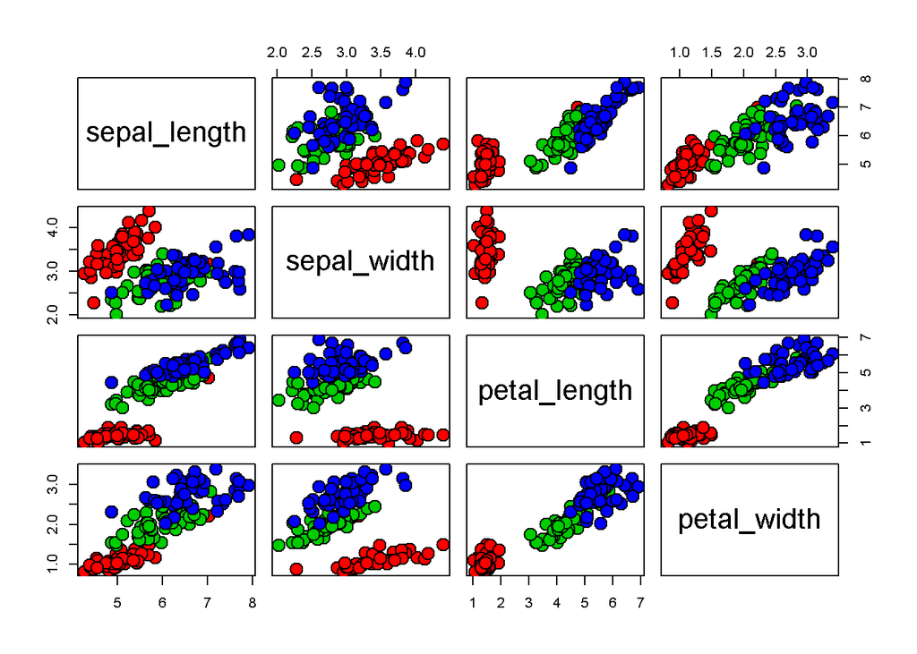

```r
pairs(iris_dna[1:4], pch = 21,cex = 2,bg = c("red", "green3", "blue")[unclass(iris$species)])
```

## Séparation des epèces de fleurs

```r
iris_setosa = iris_dna[iris_dna["species"] == "setosa",]
iris_virginica = iris_dna[iris_dna["species"] == "virginica",]
iris_versicolor = iris_dna[iris_dna["species"] == "versicolor",]
```

# 2ème partie: Réponses aux Questions

## Question 1: Calcul des coéfficients de corrélation linéaire

### **petal_width en fonction de petal_length**

```r
x = iris_dna$petal_length
y = iris_dna$petal_width
model1 = lm(y ~ x)
summary(model1)$r.squared
```

```
## [1] 0.8871412
```

```r
x = iris_dna$petal_length
y = iris_dna$sepal_width
model2 =lm(y ~ x)
summary(model2)$r.squared
```

```
## [1] 0.1940728
```

## Question 3: Régressions linéaires

- **cas 1:** petal_width = a*petal_length + b + rÃ©sidu

```r
x = iris_dna$petal_length
y = iris_dna$petal_width
fit = lm(y ~ x)
coeffs1 = coef(fit)
sprintf(" Estimations obtenues: a = %f et b = %f",coeffs1[2], coeffs1[1])
```

```
## [1] " Estimations obtenues: a = 0.385994 et b = 0.509268"
```

- **cas 2:** sepal_width = a*petal_width + b + rÃ©sidu

```r
x = iris_setosa$petal_width
y = iris_setosa$sepal_width
fit = lm(y ~ x)
coeffs2 = coef(fit)
sprintf("Estimations obtenues: a = %f et b = %f",coeffs2[2], coeffs2[1])
```

```
## [1] "Estimations obtenues: a = 1.787501 et b = 1.459327"
```

- **cas 3:** sepal_width = a*petal_width + b + rÃ©sidu

```r
x = iris_virginica$petal_width
y = iris_virginica$sepal_width
fit = lm(y ~ x)
coeffs3 = coef(fit)
sprintf("Estimations obtenues: a = %f et b = %f",coeffs3[2], coeffs3[1])
```

```
## [1] "Estimations obtenues: a = 0.699251 et b = 1.037743"
```

- **cas 4**: sepal_width = a*petal_width + b + rÃ©sidu

```r
x = iris_versicolor$petal_width
y = iris_versicolor$sepal_width
fit = lm(y ~ x)
coeffs4 = coef(fit)
sprintf("Estimations obtenues: a = %f et b = %f",coeffs4[2], coeffs4[1])
```

```
## [1] "Estimations obtenues: a = 0.973570 et b = 0.809489"
```

## Question 4: Imputation des valeurs manquantes par les valeurs prÃ©dites

```r
coeffs = list(
    "cas 1" = list('a'=coeffs1[2] , 'b'=coeffs1[1]),
    "cas 2" = list('a'=coeffs2[2] , 'b'=coeffs2[1]),
    "cas 3" = list('a'=coeffs3[2] , 'b'=coeffs3[1]),
    "cas 4" = list('a'=coeffs4[2] , 'b'=coeffs4[1])
)
lignes_modifiees = c()
for(i in 1:nrow(iris)){ # pour chaque individu de iris,...
    individu = iris[i,]
    if(is.na(individu["petal_width"])){ #... on test si individu["petal_width"] est nul.
a = coeffs[["cas 1"]][['a']]
        b = coeffs[["cas 1"]][['b']]
        X = individu["petal_length"]
        Y = a*X + b
        iris[i,"petal_width"] = Y # on remplace la valeur manquante par Y
        lignes_modifiees = c(lignes_modifiees, i)
        print(sprintf("On a complÃ©tÃ© petal_width par %f a partir de petal_length=%f",Y,X))
    }
    if(is.na(individu["sepal_width"])){
        espece = individu["species"]
        a = coeffs[["cas 4"]][['a']]
        b = coeffs[["cas 4"]][['b']]
        X = individu["petal_width"]
        Y = a*X + b
        iris[i, "sepal_width"] = Y
        lignes_modifiees = c(lignes_modifiees,i)
        print(sprintf("On a complÃ©tÃ© sepal_width par %f a partir de l'espece %s et de petal_width=%f",Y,espece,X))
    }
}
```

```
## [1] "On a complÃ©tÃ© sepal_width par 1.785341 a partir de l'espece 1 et de petal_width=1.002344"
## [1] "On a complÃ©tÃ© petal_width par 2.063990 a partir de petal_length=4.027838"
## [1] "On a complÃ©tÃ© sepal_width par 3.009714 a partir de l'espece 2 et de petal_width=2.259954"
## [1] "On a complÃ©tÃ© sepal_width par 4.043566 a partir de l'espece 3 et de petal_width=3.321872"
```

```r
print("Lignes modifiÃ©es:")
```

```
## [1] "Lignes modifiÃ©es:"
```

```r
print(lignes_modifiees)
```

```
## [1]   4  54  62 101
```

```r
 DT::datatable(iris)
```

|  | sepal_length | sepal_width | petal_length | petal_width | species |
| --- | --- | --- | --- | --- | --- |
| 1 | 5.13872794332592 | 3.47011771112961 | 1.44101535144893 | 1.09487299541502 | setosa |
| 2 | 4.84987279355354 | 3.03493074310781 | 1.41493148192258 | 0.968687007058673 | setosa |
| 3 | 4.7158428396415 | 3.23908254593477 | 1.29530859938631 | 1.00664303607456 | setosa |
| 4 | 4.60374742681394 | 1.78534143149181 | 1.48061611668186 | 1.00234356763262 | setosa |
| 5 | 4.98874377808404 | 3.64504936296645 | 1.41752678578741 | 1.12294686459989 | setosa |
| 6 | 5.43082061705992 | 3.88407294205571 | 1.69953407574969 | 1.37070761934706 | setosa |
| 7 | 4.53306516840982 | 3.3968214269536 | 1.41425639616091 | 1.15870962084568 | setosa |
| 8 | 5.01491793621289 | 3.44465150396049 | 1.49335176878984 | 1.05673072185001 | setosa |
| 9 | 4.42167083259912 | 2.86753869232846 | 1.4051217606734 | 0.920299180197713 | setosa |
| 10 | 4.89929242950976 | 3.1055391410045 | 1.5216695502387 | 0.890831152076926 | setosa |

[output cut: 140 more lines]